# Risk Factor Analysis

## Outcome Variable

**Outcome Variable:** s03rec24

## Predictor Variables

**Intervention Variable:** anywast06

**Adjustment Set:**

- arm
- sex
- W_mage
- meducyrs
- hhwealth_quart
- month
- brthmon
- W_parity
- delta_W_mage
- delta_meducyrs
- delta_hhwealth_quart
- delta_month
- delta_brthmon
- delta_W_parity

## Stratifying Variables

The analysis was stratified on these variable(s):

- studyid
- country

## Data Summary

| studyid | country | anywast06 | s03rec24 | n_cell | n |
| --- | --- | --- | --- | --- | --- |
| ki0047075b-MAL-ED | BANGLADESH | 0 | 0 | 184 | 247 |
| ki0047075b-MAL-ED | BANGLADESH | 0 | 1 | 7 | 247 |
| ki0047075b-MAL-ED | BANGLADESH | 1 | 0 | 55 | 247 |
| ki0047075b-MAL-ED | BANGLADESH | 1 | 1 | 1 | 247 |
| ki0047075b-MAL-ED | BRAZIL | 0 | 0 | 191 | 223 |
| ki0047075b-MAL-ED | BRAZIL | 0 | 1 | 18 | 223 |
| ki0047075b-MAL-ED | BRAZIL | 1 | 0 | 14 | 223 |
| ki0047075b-MAL-ED | BRAZIL | 1 | 1 | 0 | 223 |
| ki0047075b-MAL-ED | INDIA | 0 | 0 | 159 | 246 |
| ki0047075b-MAL-ED | INDIA | 0 | 1 | 9 | 246 |
| ki0047075b-MAL-ED | INDIA | 1 | 0 | 74 | 246 |
| ki0047075b-MAL-ED | INDIA | 1 | 1 | 4 | 246 |
| ki0047075b-MAL-ED | NEPAL | 0 | 0 | 187 | 238 |
| ki0047075b-MAL-ED | NEPAL | 0 | 1 | 8 | 238 |
| ki0047075b-MAL-ED | NEPAL | 1 | 0 | 40 | 238 |
| ki0047075b-MAL-ED | NEPAL | 1 | 1 | 3 | 238 |
| ki0047075b-MAL-ED | PERU | 0 | 0 | 256 | 284 |
| ki0047075b-MAL-ED | PERU | 0 | 1 | 18 | 284 |
| ki0047075b-MAL-ED | PERU | 1 | 0 | 9 | 284 |
| ki0047075b-MAL-ED | PERU | 1 | 1 | 1 | 284 |
| ki0047075b-MAL-ED | SOUTH AFRICA | 0 | 0 | 252 | 302 |
| ki0047075b-MAL-ED | SOUTH AFRICA | 0 | 1 | 16 | 302 |
| ki0047075b-MAL-ED | SOUTH AFRICA | 1 | 0 | 31 | 302 |
| ki0047075b-MAL-ED | SOUTH AFRICA | 1 | 1 | 3 | 302 |
| ki0047075b-MAL-ED | TANZANIA, UNITED REPUBLIC OF | 0 | 0 | 241 | 253 |
| ki0047075b-MAL-ED | TANZANIA, UNITED REPUBLIC OF | 0 | 1 | 1 | 253 |
| ki0047075b-MAL-ED | TANZANIA, UNITED REPUBLIC OF | 1 | 0 | 11 | 253 |
| ki0047075b-MAL-ED | TANZANIA, UNITED REPUBLIC OF | 1 | 1 | 0 | 253 |
| ki1000108-CMC-V-BCS-2002 | INDIA | 0 | 0 | 167 | 367 |
| ki1000108-CMC-V-BCS-2002 | INDIA | 0 | 1 | 5 | 367 |
| ki1000108-CMC-V-BCS-2002 | INDIA | 1 | 0 | 183 | 367 |
| ki1000108-CMC-V-BCS-2002 | INDIA | 1 | 1 | 12 | 367 |
| ki1000108-IRC | INDIA | 0 | 0 | 148 | 410 |
| ki1000108-IRC | INDIA | 0 | 1 | 18 | 410 |
| ki1000108-IRC | INDIA | 1 | 0 | 234 | 410 |
| ki1000108-IRC | INDIA | 1 | 1 | 10 | 410 |
| ki1000109-EE | PAKISTAN | 0 | 0 | 244 | 350 |
| ki1000109-EE | PAKISTAN | 0 | 1 | 0 | 350 |
| ki1000109-EE | PAKISTAN | 1 | 0 | 106 | 350 |
| ki1000109-EE | PAKISTAN | 1 | 1 | 0 | 350 |
| ki1000109-ResPak | PAKISTAN | 0 | 0 | 100 | 166 |
| ki1000109-ResPak | PAKISTAN | 0 | 1 | 0 | 166 |
| ki1000109-ResPak | PAKISTAN | 1 | 0 | 66 | 166 |
| ki1000109-ResPak | PAKISTAN | 1 | 1 | 0 | 166 |
| ki1017093b-PROVIDE | BANGLADESH | 0 | 0 | 498 | 690 |
| ki1017093b-PROVIDE | BANGLADESH | 0 | 1 | 16 | 690 |
| ki1017093b-PROVIDE | BANGLADESH | 1 | 0 | 170 | 690 |
| ki1017093b-PROVIDE | BANGLADESH | 1 | 1 | 6 | 690 |
| ki1066203-TanzaniaChild2 | TANZANIA, UNITED REPUBLIC OF | 0 | 0 | 1952 | 2276 |
| ki1066203-TanzaniaChild2 | TANZANIA, UNITED REPUBLIC OF | 0 | 1 | 2 | 2276 |
| ki1066203-TanzaniaChild2 | TANZANIA, UNITED REPUBLIC OF | 1 | 0 | 322 | 2276 |
| ki1066203-TanzaniaChild2 | TANZANIA, UNITED REPUBLIC OF | 1 | 1 | 0 | 2276 |
| ki1101329-Keneba | GAMBIA | 0 | 0 | 1839 | 2285 |
| ki1101329-Keneba | GAMBIA | 0 | 1 | 69 | 2285 |
| ki1101329-Keneba | GAMBIA | 1 | 0 | 366 | 2285 |
| ki1101329-Keneba | GAMBIA | 1 | 1 | 11 | 2285 |
| ki1113344-GMS-Nepal | NEPAL | 0 | 0 | 800 | 1188 |
| ki1113344-GMS-Nepal | NEPAL | 0 | 1 | 26 | 1188 |
| ki1113344-GMS-Nepal | NEPAL | 1 | 0 | 358 | 1188 |
| ki1113344-GMS-Nepal | NEPAL | 1 | 1 | 4 | 1188 |
| ki1114097-CMIN | BANGLADESH | 0 | 0 | 204 | 259 |
| ki1114097-CMIN | BANGLADESH | 0 | 1 | 10 | 259 |
| ki1114097-CMIN | BANGLADESH | 1 | 0 | 44 | 259 |
| ki1114097-CMIN | BANGLADESH | 1 | 1 | 1 | 259 |
| ki1114097-CMIN | PERU | 0 | 0 | 591 | 634 |
| ki1114097-CMIN | PERU | 0 | 1 | 1 | 634 |
| ki1114097-CMIN | PERU | 1 | 0 | 42 | 634 |
| ki1114097-CMIN | PERU | 1 | 1 | 0 | 634 |
| ki1114097-CONTENT | PERU | 0 | 0 | 196 | 214 |
| ki1114097-CONTENT | PERU | 0 | 1 | 14 | 214 |
| ki1114097-CONTENT | PERU | 1 | 0 | 4 | 214 |
| ki1114097-CONTENT | PERU | 1 | 1 | 0 | 214 |

The following strata were considered:

- studyid: ki0047075b-MAL-ED, country: BANGLADESH
- studyid: ki0047075b-MAL-ED, country: BRAZIL
- studyid: ki0047075b-MAL-ED, country: INDIA
- studyid: ki0047075b-MAL-ED, country: NEPAL
- studyid: ki0047075b-MAL-ED, country: PERU
- studyid: ki0047075b-MAL-ED, country: SOUTH AFRICA
- studyid: ki0047075b-MAL-ED, country: TANZANIA, UNITED REPUBLIC OF
- studyid: ki1000108-CMC-V-BCS-2002, country: INDIA
- studyid: ki1000108-IRC, country: INDIA
- studyid: ki1000109-EE, country: PAKISTAN
- studyid: ki1000109-ResPak, country: PAKISTAN
- studyid: ki1017093b-PROVIDE, country: BANGLADESH
- studyid: ki1066203-TanzaniaChild2, country: TANZANIA, UNITED REPUBLIC OF
- studyid: ki1101329-Keneba, country: GAMBIA
- studyid: ki1113344-GMS-Nepal, country: NEPAL
- studyid: ki1114097-CMIN, country: BANGLADESH
- studyid: ki1114097-CMIN, country: PERU
- studyid: ki1114097-CONTENT, country: PERU

### Dropped Strata

Some strata were dropped due to rare outcomes:

- studyid: ki0047075b-MAL-ED, country: BANGLADESH
- studyid: ki0047075b-MAL-ED, country: BRAZIL
- studyid: ki0047075b-MAL-ED, country: INDIA
- studyid: ki0047075b-MAL-ED, country: NEPAL
- studyid: ki0047075b-MAL-ED, country: PERU
- studyid: ki0047075b-MAL-ED, country: SOUTH AFRICA
- studyid: ki0047075b-MAL-ED, country: TANZANIA, UNITED REPUBLIC OF
- studyid: ki1000109-EE, country: PAKISTAN
- studyid: ki1000109-ResPak, country: PAKISTAN
- studyid: ki1066203-TanzaniaChild2, country: TANZANIA, UNITED REPUBLIC OF
- studyid: ki1113344-GMS-Nepal, country: NEPAL
- studyid: ki1114097-CMIN, country: BANGLADESH
- studyid: ki1114097-CMIN, country: PERU
- studyid: ki1114097-CONTENT, country: PERU

## Methods Detail

We’re interested in the causal parameters $E[Y_a]$ for all values of $a \in \mathcal{A}$. These parameters represent the mean outcome if, possibly contrary to fact, we intervened to set all units to have $A=a$. Under the randomization and positivity assumptions, these are identified by the statistical parameters $\psi_a=E_W[E_{Y|A,W}(Y|A=a,W)]$. In addition, we’re interested in the mean of $Y$, $E[Y]$ under no intervention (the observed mean). We will estimate these parameters by using SuperLearner to fit the relevant likelihood factors – $E_{Y|A,W}(Y|A=a,W)$ and $p(A=a|W)$, and then updating our likelihood fit using a joint TMLE.

For unadjusted analyses ($W=\{\}$), initial likelihoods were estimated using Lrnr_glm to estimate the simple $E(Y|A)$ and Lrnr_mean to estimate $p(A)$. For adjusted analyses, a small library containing Lrnr_glmnet, Lrnr_xgboost, and Lrnr_mean was used.

Having estimated these parameters, we will then use the delta method to estimate relative risks and attributable risks relative to a prespecified baseline level of $A$.

# Results Detail

## Results Plots

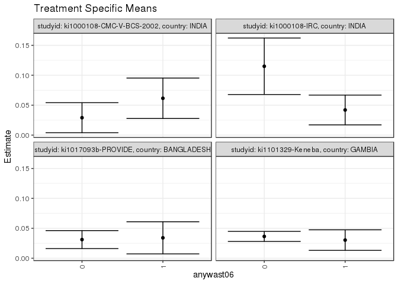

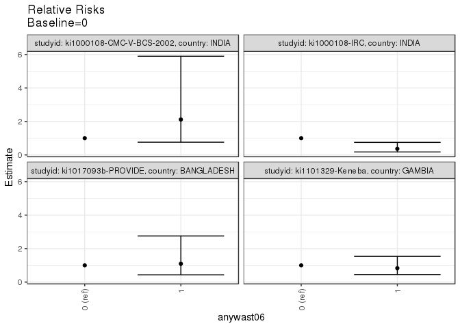

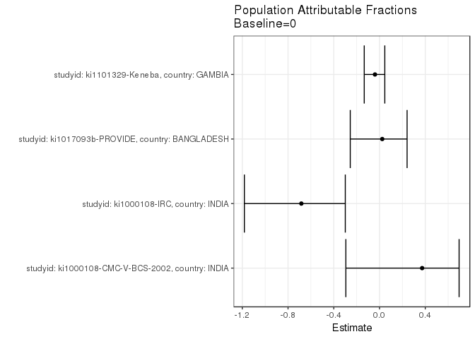

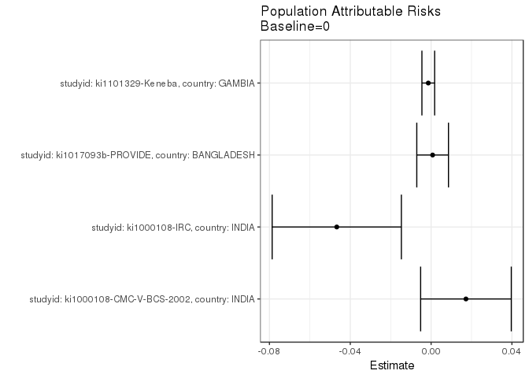

## Results Table

### Parameter: TSM

| studyid | country | intervention_level | baseline_level | estimate | ci_lower | ci_upper |
| --- | --- | --- | --- | --- | --- | --- |
| ki1000108-CMC-V-BCS-2002 | INDIA | 0 | NA | 0.0290698 | 0.0039283 | 0.0542113 |
| ki1000108-CMC-V-BCS-2002 | INDIA | 1 | NA | 0.0615385 | 0.0277627 | 0.0953142 |
| ki1000108-IRC | INDIA | 0 | NA | 0.1149808 | 0.0678077 | 0.1621538 |
| ki1000108-IRC | INDIA | 1 | NA | 0.0419898 | 0.0170903 | 0.0668893 |
| ki1017093b-PROVIDE | BANGLADESH | 0 | NA | 0.0311284 | 0.0161041 | 0.0461527 |
| ki1017093b-PROVIDE | BANGLADESH | 1 | NA | 0.0340909 | 0.0072626 | 0.0609193 |
| ki1101329-Keneba | GAMBIA | 0 | NA | 0.0364065 | 0.0279987 | 0.0448143 |
| ki1101329-Keneba | GAMBIA | 1 | NA | 0.0302933 | 0.0130962 | 0.0474904 |

### Parameter: E(Y)

| studyid | country | intervention_level | baseline_level | estimate | ci_lower | ci_upper |
| --- | --- | --- | --- | --- | --- | --- |
| ki1000108-CMC-V-BCS-2002 | INDIA | NA | NA | 0.0463215 | 0.0247888 | 0.0678543 |
| ki1000108-IRC | INDIA | NA | NA | 0.0682927 | 0.0438464 | 0.0927390 |
| ki1017093b-PROVIDE | BANGLADESH | NA | NA | 0.0318841 | 0.0187654 | 0.0450027 |
| ki1101329-Keneba | GAMBIA | NA | NA | 0.0350109 | 0.0274728 | 0.0425491 |

### Parameter: RR

| studyid | country | intervention_level | baseline_level | estimate | ci_lower | ci_upper |
| --- | --- | --- | --- | --- | --- | --- |
| ki1000108-CMC-V-BCS-2002 | INDIA | 0 | 0 | 1.0000000 | 1.0000000 | 1.0000000 |
| ki1000108-CMC-V-BCS-2002 | INDIA | 1 | 0 | 2.1169231 | 0.7600586 | 5.8960761 |
| ki1000108-IRC | INDIA | 0 | 0 | 1.0000000 | 1.0000000 | 1.0000000 |
| ki1000108-IRC | INDIA | 1 | 0 | 0.3651897 | 0.1774952 | 0.7513641 |
| ki1017093b-PROVIDE | BANGLADESH | 0 | 0 | 1.0000000 | 1.0000000 | 1.0000000 |
| ki1017093b-PROVIDE | BANGLADESH | 1 | 0 | 1.0951705 | 0.4350587 | 2.7568656 |
| ki1101329-Keneba | GAMBIA | 0 | 0 | 1.0000000 | 1.0000000 | 1.0000000 |
| ki1101329-Keneba | GAMBIA | 1 | 0 | 0.8320859 | 0.4507251 | 1.5361180 |

### Parameter: PAR

| studyid | country | intervention_level | baseline_level | estimate | ci_lower | ci_upper |
| --- | --- | --- | --- | --- | --- | --- |
| ki1000108-CMC-V-BCS-2002 | INDIA | 0 | NA | 0.0172518 | -0.0051820 | 0.0396855 |
| ki1000108-IRC | INDIA | 0 | NA | -0.0466881 | -0.0786636 | -0.0147126 |
| ki1017093b-PROVIDE | BANGLADESH | 0 | NA | 0.0007557 | -0.0070881 | 0.0085994 |
| ki1101329-Keneba | GAMBIA | 0 | NA | -0.0013956 | -0.0045469 | 0.0017558 |

### Parameter: PAF

| studyid | country | intervention_level | baseline_level | estimate | ci_lower | ci_upper |
| --- | --- | --- | --- | --- | --- | --- |
| ki1000108-CMC-V-BCS-2002 | INDIA | 0 | NA | 0.3724350 | -0.2943792 | 0.6957323 |
| ki1000108-IRC | INDIA | 0 | NA | -0.6836472 | -1.1817491 | -0.2992639 |
| ki1017093b-PROVIDE | BANGLADESH | 0 | NA | 0.0237000 | -0.2558471 | 0.2410210 |
| ki1101329-Keneba | GAMBIA | 0 | NA | -0.0398607 | -0.1335519 | 0.0460868 |